# ggsoccer

Tymoteusz Urban

2022-12-22

# Opis

ggsoccer jest pakietem służącym do generowania piłkarskiego boiska, na którym następnie wizualizowane są dane. Dzięki temu, że ggsoccer jest rozszerzeniem ggplot, wizualizacje można dostosowywać przy pomocy standardowych funkcji ggplot. Najważniejszą funkcją z pakietu jest annotate_pitch() - to ona odpowiada za wygenerowanie boiska. Użycie jest bardzo proste: najpierw używamy funkcji ggplot(), następnie po ‘+’ wpisujemy annotate_pitch(). Po kolejnym plusie podajemy typ wykresu, którego chcemy użyć do wizualizacji naszych danych np. geom_segment czy geom_point (tam musimy określić dane, które będziemy wizualizować). Funkcja annotate_pitch() rysuje boisko o odpowiednich wymiarach i układzie współrzędnych, które określamy w polu dimensions. ggsoccer posiada przygotowane specyfikacje boiska dla kilku popularnych dostarczycieli danych piłkarskich takich jak Opta (domyślne) czy StatsBomb (przykładowo niektóre firmy używają układu współrzędnych 100x100, a inne 120x80). Przy tworzeniu wykresu warto użyć także theme_pitch() - zostawia ona jedynie samo boisko a niepotrzebne elementy takie jak skala czy siatka są usuwane. Boisko możemy oczywiście obracać (przy pomocy coord_flip i scale_y_reverse), przycinać (xlim i ylim), kolorować (ustawiając pola colour i fill) lub zmieniać typ linii (linetype) i wygląd bramek (goals). ggsoccer świetnie się nadaje do przedstawiania większości statystyk piłkarskich - łatwo tworzyć wizualizacje podań i strzałów, mapy ciepła pozycji i pressingów a także mapy przedstawiające miejsca dryblingów, pojedynków czy fauli. Trzeba pamiętać, że ggsoccer jest przydatny tylko do danych, w których mamy określoną lokalizację konkretnych zdarzeń boiskowych.

# Przykładowa wizualizacja

W przykładzie przygotujemy wizualizację strzałów z finału Ligi Mistrzów z sezonu 2013/14. Z lewej strony boiska będą znajdować się strzały Realu Madryt, a z drugiej Atletico (mała uwaga - proszę pamiętać, że atletico to nie klub). Punkty będą oznaczały miejsca, skąd został oddany strzał, a im większe kółko, tym wyższa wartość xG (prawdopodobieństwo, że po strzale z danego miejsca padnie gol). Co więcej, zamalowany punkt oznacza, że po strzale padła bramka. Dane do wizualizacji pochodzą z pakietu StatsBombR.

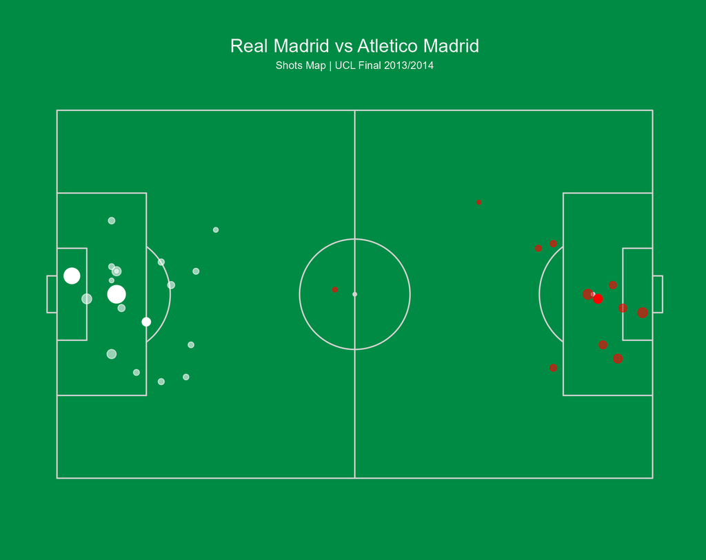

# Kod wizualizacji

```r
# Przygotowanie danych
real_shot <- match_df %>%
  filter(type.name == 'Shot') %>%
  filter(team.name == 'Real Madrid') %>%
  select(location.x, location.y, shot.statsbomb_xg, shot.outcome.name)
atletico_shot <- match_df %>%
  filter(type.name == 'Shot') %>%
  filter(team.name == 'Atlético Madrid') %>%
  select(location.x, location.y, shot.statsbomb_xg, shot.outcome.name)

# Wizualizacja z użyciem ggsoccer
plot <- ggplot() +
  annotate_pitch(dimensions = pitch_statsbomb, colour='lightgrey', fill='springgreen4') +
  geom_point(data=atletico_shot, aes(x=location.x, y=location.y, size=shot.statsbomb_xg),
             color="red", alpha = ifelse(atletico_shot$shot.outcome.name == 'Goal', 1, 0.6)) +
  geom_point(data=real_shot, aes(x=120-location.x, y=location.y, size=shot.statsbomb_xg),
             color="white", alpha = ifelse(real_shot$shot.outcome.name == 'Goal', 1, 0.6)) +
  labs(
    title="Real Madrid vs Atletico Madrid",
    subtitle = "Shots Map | UCL Final 2013/2014",
  ) +
  theme_pitch() +
  theme(
    plot.background = element_rect(fill='springgreen4', color='springgreen4'),
    panel.background = element_rect(fill='springgreen4', color='springgreen4'),
    text = element_text(color='white'),
    plot.title = element_text(hjust=0.5, vjust=0, size=14),
    plot.subtitle = element_text(hjust=0.5, vjust=0, size=8),
    legend.position = "none"
  )
```